# chap4_line_graphs

J.H AHN

2022 1 6

### 4.1 Making a basic line graph

```r
BOD
```

```
##   Time demand
## 1    1    8.3
## 2    2   10.3
## 3    3   19.0
## 4    4   16.0
## 5    5   15.6
## 6    7   19.8
```

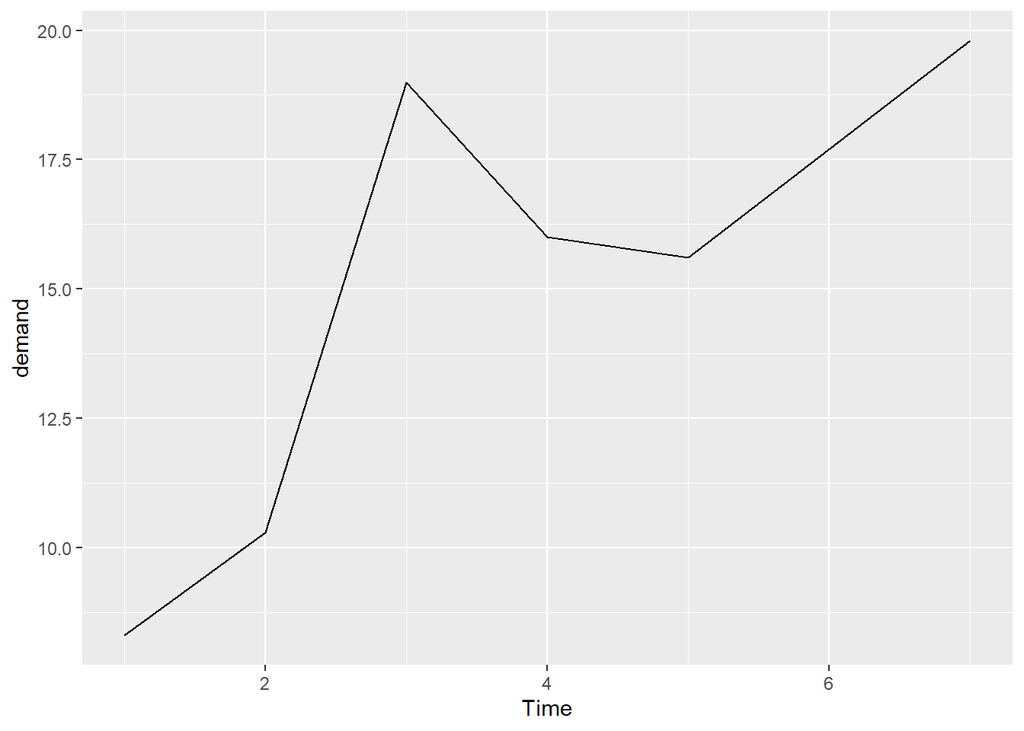

```r
BOD %>%
  ggplot(aes(Time, demand)) +
  geom_line()
```

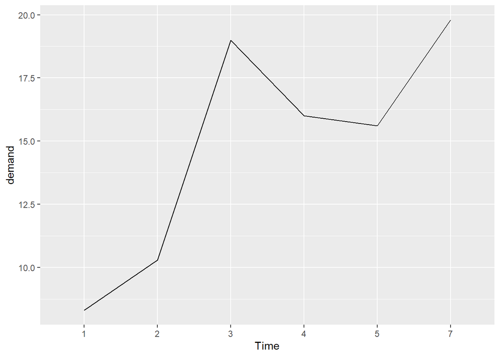

```r
BOD1 <- BOD
BOD1$Time <- factor(BOD1$Time)

BOD1 %>%
  ggplot(aes(Time, demand, group = 1)) +
  geom_line()
```

BOD data에는 Time = 6에 해당하는 정보가 없다.  
그래서 Time을 factor형으로 바꾸면 categorical variable로 인식해서 X=6에 해당하는 값을 나타내지 않는다.

ggplot2에서 y 범위는 데이터에 있는 y값들이 모두 들어갈 수 있게 자동으로 정해지는데 때에 따라 y가 0에서 시작하는 것이 필요할 경우가 있다.  
이럴 경우 `ylim()`을 설정하거나, `expand_limits()`을 쓰는 방법이 있다.

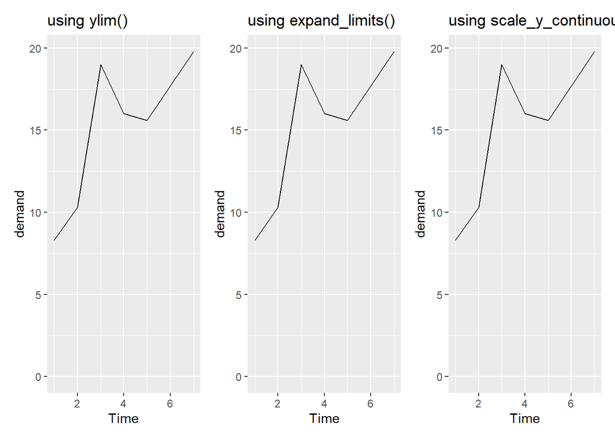

```r
ex_ylim <-
  BOD %>%
  ggplot(aes(Time, demand)) +
  geom_line() +
  labs(title = "using ylim()") +
  ylim(0, max(BOD$demand))

ex_exlim <-
  BOD %>%
  ggplot(aes(Time, demand)) +
  geom_line() +
  labs(title = "using expand_limits()") +
  expand_limits(y = 0)

ex_scale <-
  BOD %>%
  ggplot(aes(Time, demand)) +
  geom_line() +
  labs(title = "using scale_y_continuous()") +
  scale_y_continuous(limits = c(0, max(BOD$demand)))

ex_ylim + ex_exlim + ex_scale
```

### 4.3 Making a line graph with multiple lines

line graph에서 이산형 변수에 따라 선모양이나 선색깔을 다르게 하고 싶을 때는 아래와 같은 방법을 사용한다.

```r
ToothGrowth
```

```
##     len supp dose
## 1   4.2   VC  0.5
## 2  11.5   VC  0.5
## 3   7.3   VC  0.5
## 4   5.8   VC  0.5
## 5   6.4   VC  0.5
## 6  10.0   VC  0.5
## 7  11.2   VC  0.5
## 8  11.2   VC  0.5
## 9   5.2   VC  0.5
## 10  7.0   VC  0.5
## 11 16.5   VC  1.0
## 12 16.5   VC  1.0
## 13 15.2   VC  1.0
## 14 17.3   VC  1.0
```

[output cut: 46 more lines]

```r
library(plyr)
tg_old <- ddply(ToothGrowth, c("supp","dose"), summarise, length=mean(len))

tg_old
```

```
##   supp dose length
## 1   OJ  0.5  13.23
## 2   OJ  1.0  22.70
## 3   OJ  2.0  26.06
## 4   VC  0.5   7.98
## 5   VC  1.0  16.77
## 6   VC  2.0  26.14
```

```r
tg <-
  ToothGrowth %>%
  group_by(supp, dose) %>%
  dplyr::summarise(length = mean(len))
tg
```

```
## # A tibble: 6 x 3
## # Groups:   supp [2]
##   supp   dose length
##   <fct> <dbl>  <dbl>
## 1 OJ      0.5  13.2
## 2 OJ      1    22.7
## 3 OJ      2    26.1
## 4 VC      0.5   7.98
## 5 VC      1    16.8
## 6 VC      2    26.1
```

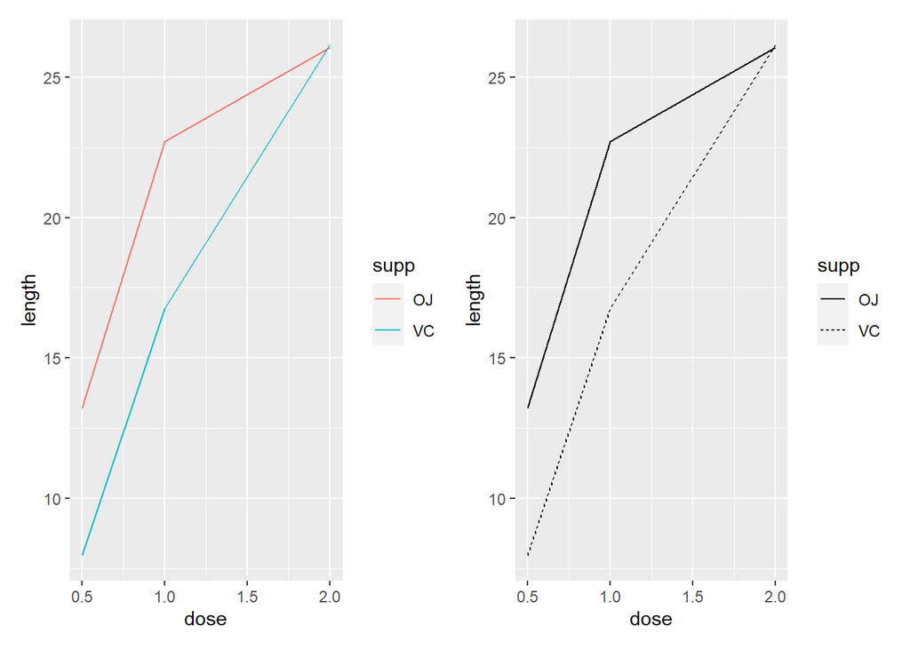

```r
diff_line <-
  tg %>%
  ggplot(aes(x = dose, y = length, color = supp)) +
  geom_line()

diff_type <-
  tg %>%
  ggplot(aes(x = dose, y = length, lty = supp)) +
  geom_line()

diff_line + diff_type
```

`tg` data를 보면 dose는 실제로 세가지 값(0.5, 1, 2)만 있다.  
만약 이것을 연속적인 값으로 보지 않고 범주로 본다면 dose값을 factor로 변환하면 된다.

```r
str(tg)
```

```
## grouped_df [6 x 3] (S3: grouped_df/tbl_df/tbl/data.frame)
##  $ supp  : Factor w/ 2 levels "OJ","VC": 1 1 1 2 2 2
##  $ dose  : num [1:6] 0.5 1 2 0.5 1 2
##  $ length: num [1:6] 13.23 22.7 26.06 7.98 16.77 ...
##  - attr(*, "groups")= tibble [2 x 2] (S3: tbl_df/tbl/data.frame)
##   ..$ supp : Factor w/ 2 levels "OJ","VC": 1 2
##   ..$ .rows: list<int> [1:2]
##   .. ..$ : int [1:3] 1 2 3
##   .. ..$ : int [1:3] 4 5 6
##   .. ..@ ptype: int(0)
##   ..- attr(*, ".drop")= logi TRUE
```

dose를 factor형으로 바꾼 후에 **group = supp**라고 추가 한 것에 주의해야 한다.  
이 구문을 넣지 않으면 ggplot()은 어떻게 데이터들을 묶어서 선을 그려야 할지 모른다.

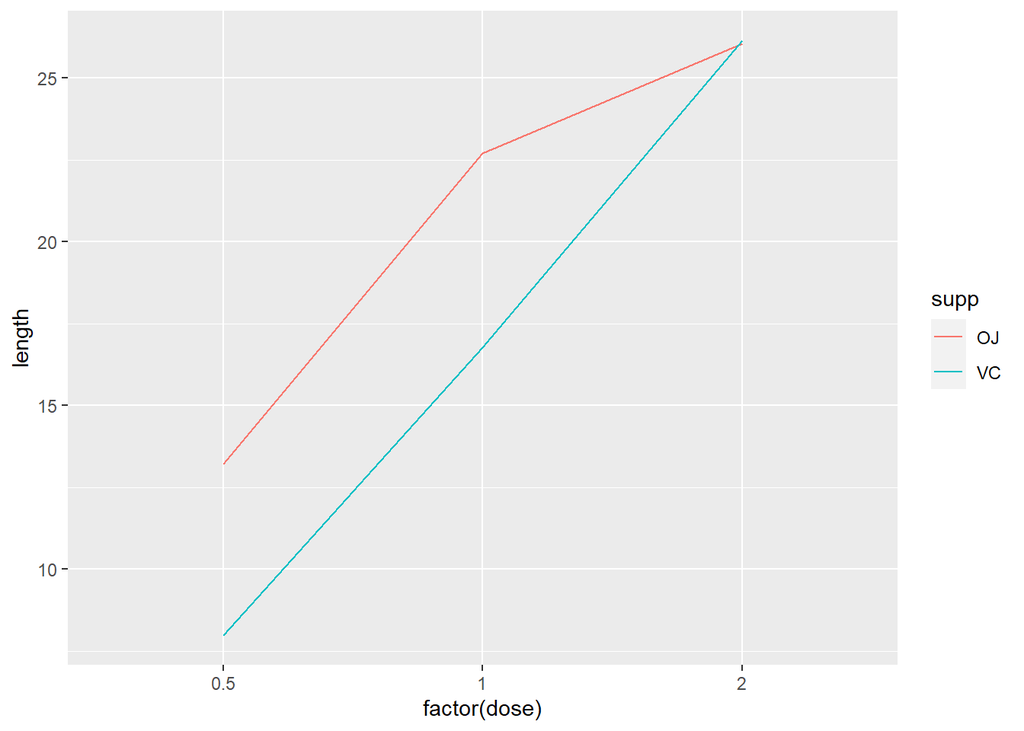

```r
tg %>%
  ggplot(aes(x = factor(dose), y = length, color = supp, group = supp)) +
  geom_line()
```

또 다른 흔한 문제 중 하나는 그룹을 잘못지어 톱니 이빨모양의 패턴이 나타나는 것이다.

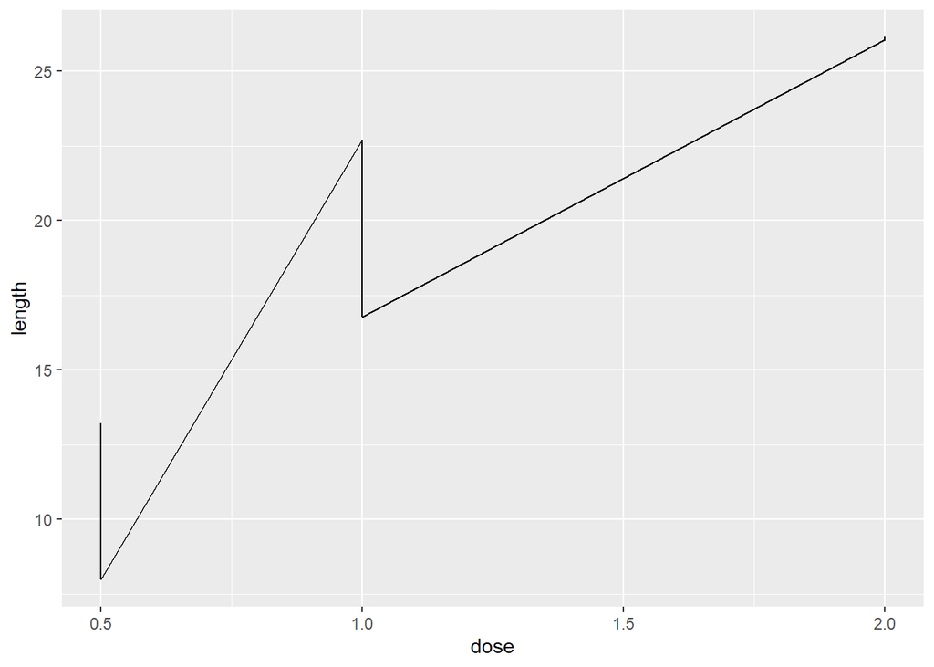

```r
tg %>%
  ggplot(aes(x = dose, y = length)) +
  geom_line()
```

이런 현상은 하나의 x값에 대응하는 여러개의 y값이 있을 때 발생한다.  
ggplot()은 모두 하나의 그룹으로 보기 때문에 이러한 현상이 발생하는 것이므로, 각각의 그룹을 지정해 주어야 한다.  
만약 이산형 변수가 aes()에서 color나 linetype으로 맵핑되어있으면 자동으로 그룹별로 선을 그려주는데, 만약 aes()에서 맵핑하지 않은 다른 변수로 그룹핑을 하려면 `group`를 사용해서 묶어줘야 한다.

만약 선을 따라 점을 넣는다면 형태나 shape이나 color와 같은 속성을 줄 수 있다.

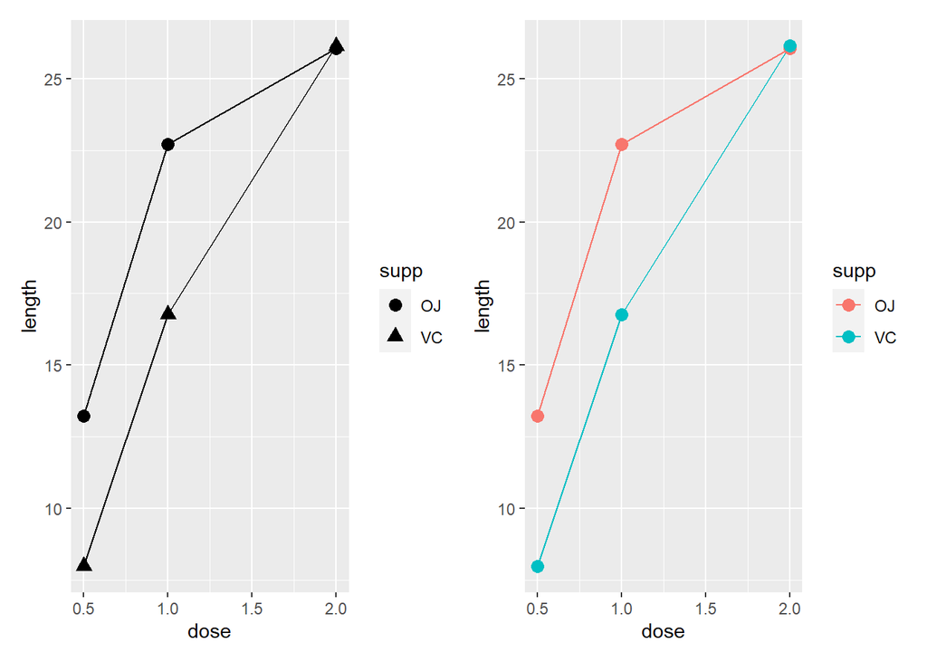

```r
shape_pt <-
  tg %>% ggplot(aes(x = dose, y = length, shape = supp)) +
  geom_line() +
  geom_point(size = 3)

color_pt <-
  tg %>% ggplot(aes(x = dose, y = length, color = supp)) +
  geom_line()+
  geom_point(size = 3)


shape_pt + color_pt
```

때로 두 점이 겹쳐져서 구별이 안 될 경우가 있다.  
이럴 때는 `position = position_dodge()`를 이용하여 점들을 좌우로 이동시켜 모두 보이게 만들 수 있다.  
`position_dodge()`값을 줄 때는 line에도 줄 수 있고, point에도 줄 수 있다.  
일반적으로 Line과 Point를 동시에 이동시켜야 선과 점이 같이 움직인다.

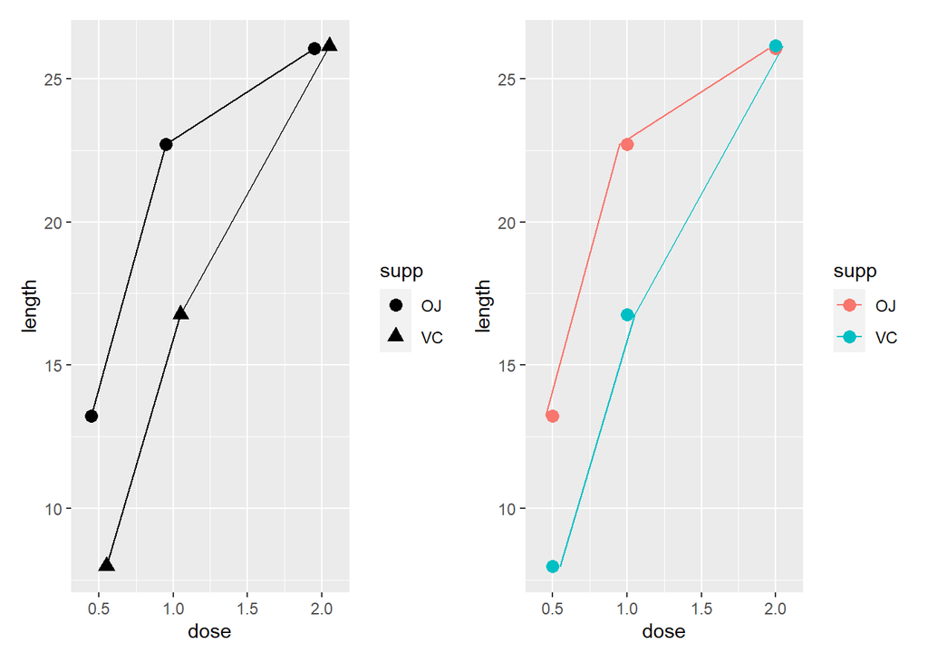

```r
shape_pt_dodge <-
  tg %>% ggplot(aes(x = dose, y = length, shape = supp)) +
  geom_line(position = position_dodge(0.2)) +
  geom_point(position = position_dodge(0.2), size = 3)

color_pt_dodge <-
  tg %>% ggplot(aes(x = dose, y = length, color = supp)) +
  geom_line(position = position_dodge(0.2))+
  geom_point(size = 3)


shape_pt_dodge + color_pt_dodge
```

### 4.4 Changing the apperance of lines

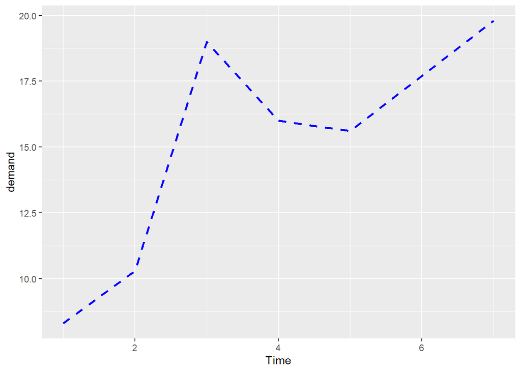

```r
BOD %>%
  ggplot(aes(x = Time, y = demand)) +
  geom_line(linetype = "dashed", size = 1, color = "#0000FF")
```

여기에 선을 하나 더 그릴 경우 선의 색깔은 팔레트를 이용하여 나오게 할 수 있다.  
`scale_color_brewer()`이나 `scale_color_manual()`을 사용하면 된다.

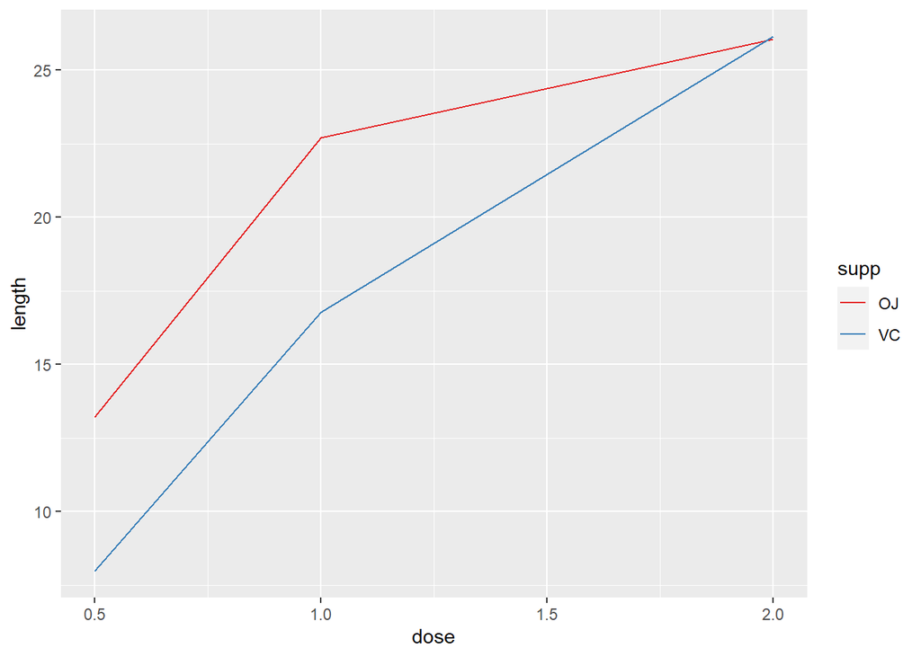

```r
tg %>%
  ggplot(aes(x = dose, y = length, color = supp)) +
  geom_line() +
  scale_color_brewer(palette = "Set1")
```

만약 모든 선에 똑같은 색깔을 주고 싶다면 aes()밖에서 색을 지정해주면 된다.  
size나 linetype, shape도 동일하다.

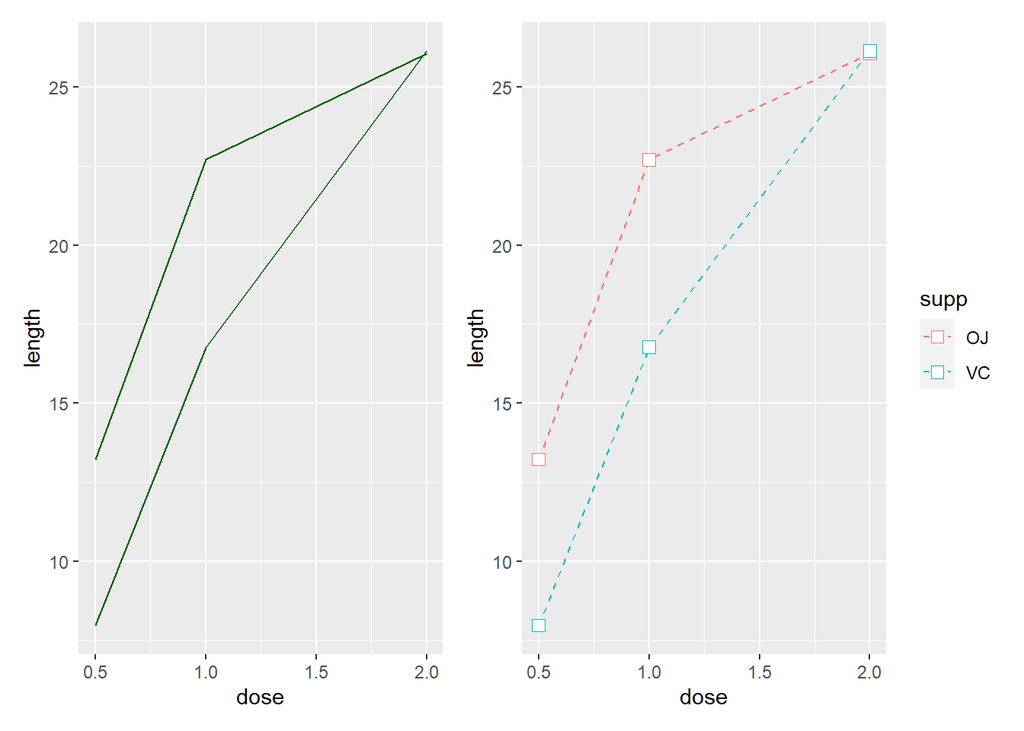

```r
color_set <-
  tg %>%
  ggplot(aes(x = dose, y = length, group = supp)) +
  geom_line(color = "#006400")

shape_set <-
  tg %>%
  ggplot(aes(x = dose, y = length, color = supp)) +
  geom_line(linetype = "dashed") +
  geom_point(shape = 22, size = 3, fill = "#FFFFFF")


color_set + shape_set
```

### 4.5 Changing the apperance of Points

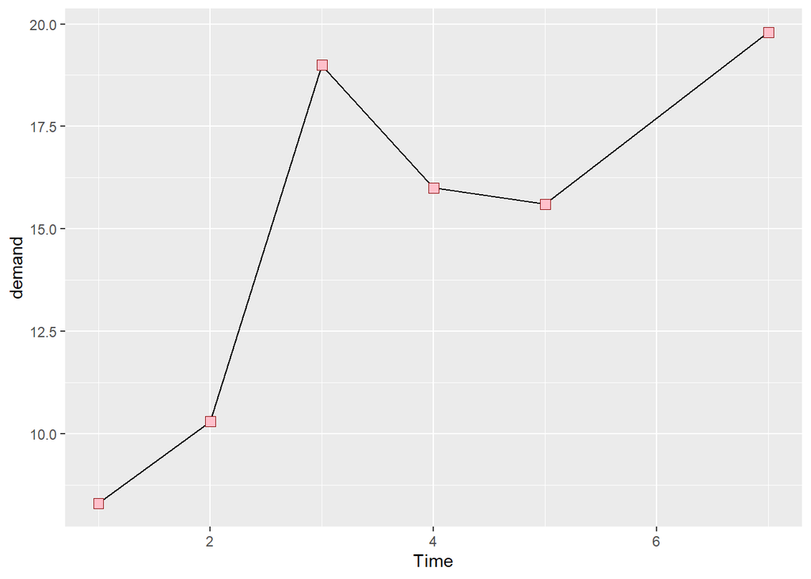

```r
BOD %>%
  ggplot(aes(x = Time, y = demand)) +
  geom_line() +
  geom_point(size = 3, shape = 22, color = "#8B0000", fill = "#FFC0CB")
```

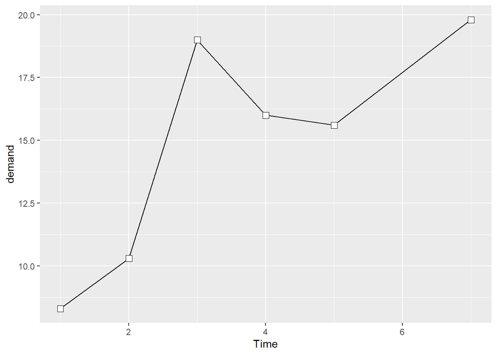

```r
BOD %>%
  ggplot(aes(x = Time, y = demand)) +
  geom_line() +
  geom_point(size = 3, shape = 22, fill = "#FFFFFF")
```

여러 선을 한 번에 그려야 할 때 일반적으로는 aes()안에 색을 다르게 할 그룹을 맵핑한다.  
하지만 R에서 기본적으로 설정된 색깔이 마음에 들지 않을 경우에는 `scale_color_brewer()`이나 `scale_color_manual()`을 이용하여 다른 팔레트를 설정할 수 있다.  
모든 point에 단일 shape이나 size를 적용하고 싶을 때는 aes()밖에 shape이나 size를 설정하면 된다.

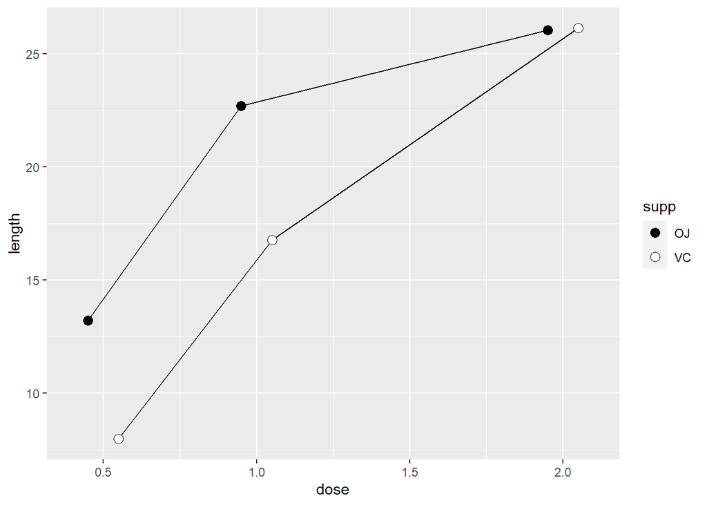

```r
tg %>%
  ggplot(aes(x = dose, y = length, fill = supp)) +
  geom_line(position = position_dodge(0.2)) +
  geom_point(shape = 21, size = 3, position = position_dodge(0.2)) +
  scale_fill_manual(values = c("black", "white"))
```

### 4.6 Making a graph with a shaded area

```r
sunspot.year
```

```
## Time Series:
## Start = 1700
## End = 1988
## Frequency = 1
##   [1]   5.0  11.0  16.0  23.0  36.0  58.0  29.0  20.0  10.0   8.0   3.0   0.0
##  [13]   0.0   2.0  11.0  27.0  47.0  63.0  60.0  39.0  28.0  26.0  22.0  11.0
##  [25]  21.0  40.0  78.0 122.0 103.0  73.0  47.0  35.0  11.0   5.0  16.0  34.0
##  [37]  70.0  81.0 111.0 101.0  73.0  40.0  20.0  16.0   5.0  11.0  22.0  40.0
##  [49]  60.0  80.9  83.4  47.7  47.8  30.7  12.2   9.6  10.2  32.4  47.6  54.0
##  [61]  62.9  85.9  61.2  45.1  36.4  20.9  11.4  37.8  69.8 106.1 100.8  81.6
##  [73]  66.5  34.8  30.6   7.0  19.8  92.5 154.4 125.9  84.8  68.1  38.5  22.8
##  [85]  10.2  24.1  82.9 132.0 130.9 118.1  89.9  66.6  60.0  46.9  41.0  21.3
##  [97]  16.0   6.4   4.1   6.8  14.5  34.0  45.0  43.1  47.5  42.2  28.1  10.1
## [109]   8.1   2.5   0.0   1.4   5.0  12.2  13.9  35.4  45.8  41.1  30.1  23.9
## [121]  15.6   6.6   4.0   1.8   8.5  16.6  36.3  49.6  64.2  67.0  70.9  47.8
## [133]  27.5   8.5  13.2  56.9 121.5 138.3 103.2  85.7  64.6  36.7  24.2  10.7
## [145]  15.0  40.1  61.5  98.5 124.7  96.3  66.6  64.5  54.1  39.0  20.6   6.7
## [157]   4.3  22.7  54.8  93.8  95.8  77.2  59.1  44.0  47.0  30.5  16.3   7.3
## [169]  37.6  74.0 139.0 111.2 101.6  66.2  44.7  17.0  11.3  12.4   3.4   6.0
## [181]  32.3  54.3  59.7  63.7  63.5  52.2  25.4  13.1   6.8   6.3   7.1  35.6
## [193]  73.0  85.1  78.0  64.0  41.8  26.2  26.7  12.1   9.5   2.7   5.0  24.4
## [205]  42.0  63.5  53.8  62.0  48.5  43.9  18.6   5.7   3.6   1.4   9.6  47.4
## [217]  57.1 103.9  80.6  63.6  37.6  26.1  14.2   5.8  16.7  44.3  63.9  69.0
## [229]  77.8  64.9  35.7  21.2  11.1   5.7   8.7  36.1  79.7 114.4 109.6  88.8
## [241]  67.8  47.5  30.6  16.3   9.6  33.2  92.6 151.6 136.3 134.7  83.9  69.4
## [253]  31.5  13.9   4.4  38.0 141.7 190.2 184.8 159.0 112.3  53.9  37.5  27.9
## [265]  10.2  15.1  47.0  93.8 105.9 105.5 104.5  66.6  68.9  38.0  34.5  15.5
## [277]  12.6  27.5  92.5 155.4 154.7 140.5 115.9  66.6  45.9  17.9  13.4  29.2
## [289] 100.2
```

```r
sunspotyear <- data.frame(
  Year = as.numeric(time(sunspot.year)),
  Sunspots = as.numeric(sunspot.year)
)

sunspotyear
```

```
##     Year Sunspots
## 1   1700      5.0
## 2   1701     11.0
## 3   1702     16.0
## 4   1703     23.0
## 5   1704     36.0
## 6   1705     58.0
## 7   1706     29.0
## 8   1707     20.0
## 9   1708     10.0
## 10  1709      8.0
## 11  1710      3.0
## 12  1711      0.0
## 13  1712      0.0
## 14  1713      2.0
```

[output cut: 275 more lines]

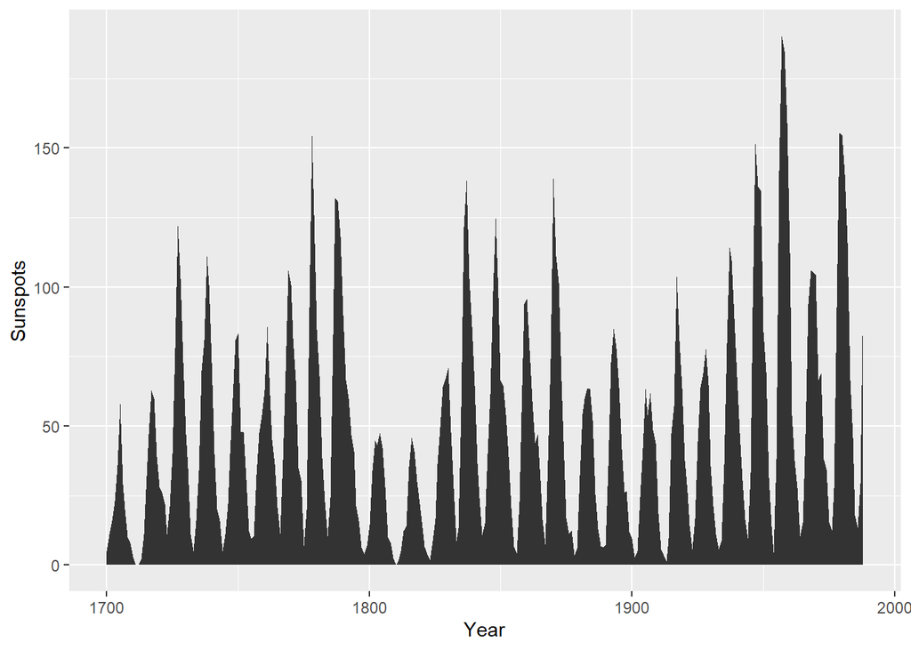

```r
sunspotyear %>%
  ggplot(aes(Year, Sunspots)) +
  geom_area()
```

default로 `geom_area()`는 dark grey에 no outline으로 그려진다.  
색을 바꾸기 위해서는 fill을 설정하고 alpha값으로 투명도를 설정한다.  
outline은 color를 설정하여 그릴 수 있다.

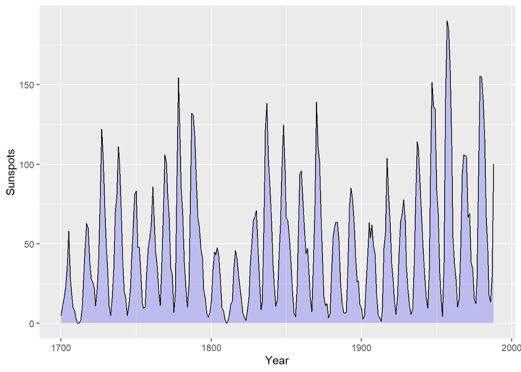

```r
sunspotyear %>%
  ggplot(aes(Year, Sunspots)) +
  geom_area(fill = "#0000FF", color = "#000000", alpha = 0.2)
```

전체 면적에 걸쳐 outline을 그리면 shade area의 처음과 끝 부분, 바닥면까지 선이 그어졌었다.  
이런 문제를 피하기 위해서 outline을 넣지말고, `geom_line()` layer를 추가하라고 되어있으나, 현재 버전에서는 geom_line()으로 그리는 것과 outline을 넣는 것과 동일하다.

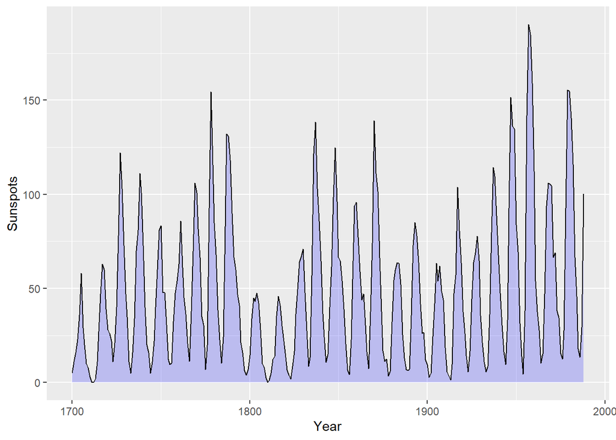

```r
sunspotyear %>%
  ggplot(aes(Year, Sunspots)) +
  geom_area(fill = "#0000FF", alpha = 0.2) +
  geom_line()
```

### 4.7 Making a stacked area graph

```r
uspopage
```

```
##     Year AgeGroup Thousands
## 1   1900       <5      9181
## 2   1900     5-14     16966
## 3   1900    15-24     14951
## 4   1900    25-34     12161
## 5   1900    35-44      9273
## 6   1900    45-54      6437
## 7   1900    55-64      4026
## 8   1900      >64      3099
## 9   1901       <5      9336
## 10  1901     5-14     17158
## 11  1901    15-24     15242
## 12  1901    25-34     12442
## 13  1901    35-44      9504
## 14  1901    45-54      6606
```

[output cut: 810 more lines]

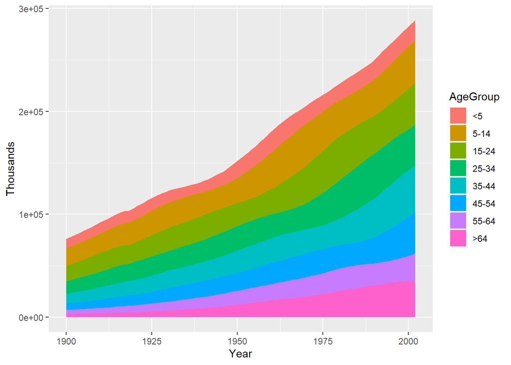

```r
uspopage %>%
  ggplot(aes(x = Year, y = Thousands, fill = AgeGroup)) +
  geom_area()
```

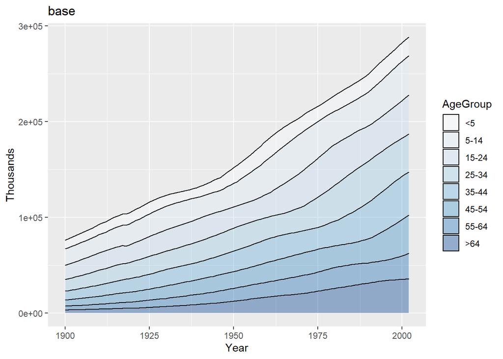

```r
uspopage %>%
  ggplot(aes(x = Year, y = Thousands, fill = AgeGroup)) +
  geom_area(color = "#000000", alpha = 0.4) +
  scale_fill_brewer(palette = "Blues") +
  labs(title = "base")
```

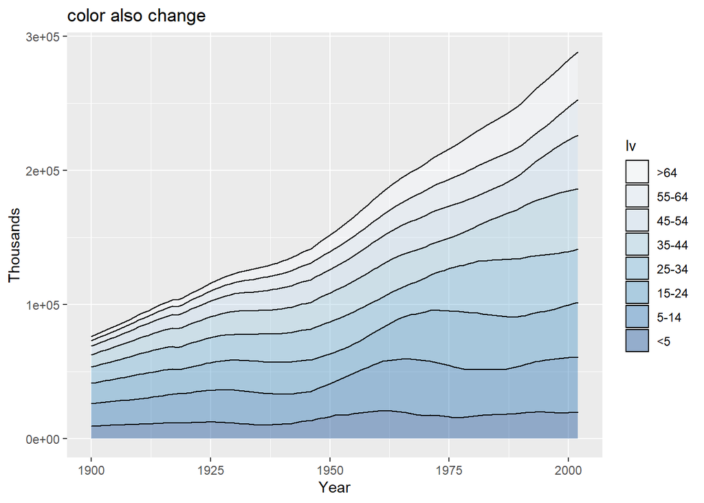

```r
lv <- factor(uspopage$AgeGroup, levels = rev(levels(uspopage$AgeGroup)))

uspopage %>%
  ggplot(aes(x = Year, y = Thousands, fill = lv)) +
  geom_area(color = "#000000", alpha = 0.4) +
  scale_fill_brewer(palette = "Blues") +
  labs(title = "color also change")
```

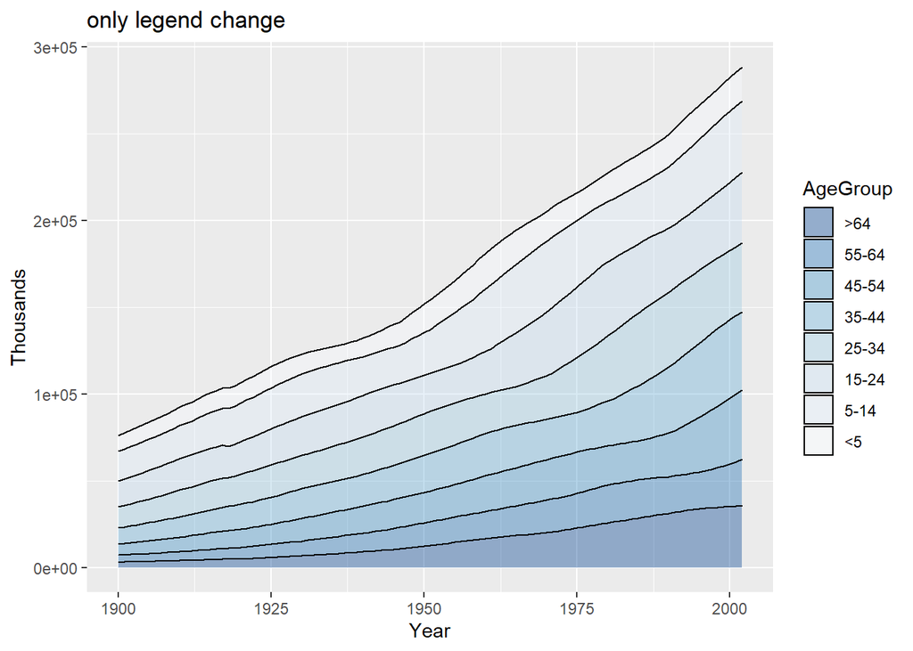

```r
uspopage %>%
  ggplot(aes(x = Year, y = Thousands, fill = AgeGroup)) +
  geom_area(color = "#000000", alpha = 0.4) +
  scale_fill_brewer(palette = "Blues") +
  guides(fill =  guide_legend(reverse = TRUE)) +
  labs(title = "only legend change")
```

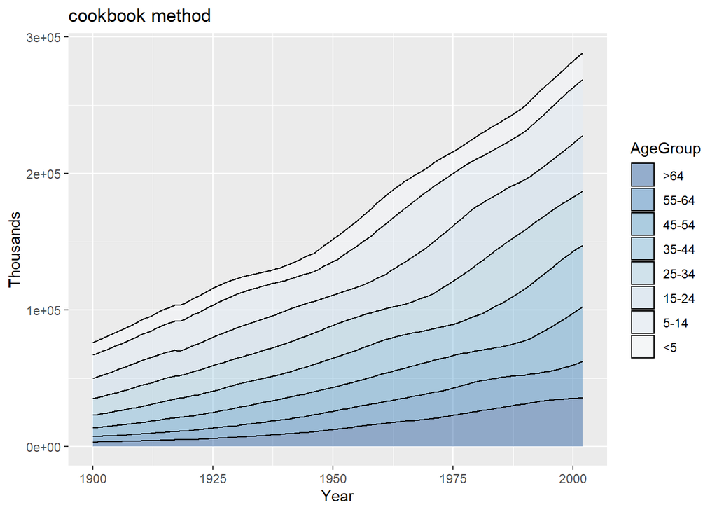

```r
uspopage %>%
  ggplot(aes(x = Year, y = Thousands, fill = AgeGroup)) +
  geom_area(color = "#000000", alpha = 0.4) +
  scale_fill_brewer(palette = "Blues", breaks = rev(levels(uspopage$AgeGroup))) +
  labs(title = "cookbook method")
```

stacking order를 바꾸는 또 다른 방법으로 `aes()`에 `order = desc(AgeGroup)`를 설정하는 것이 있다. BUT!!!  
**stacking순서를 바꾸고 싶다면 `order = desc()`를 `aes()`에 넣어주면 된다고 책에는 되어 있으나, 이는 ggplot2 ver.2.0.0에서 부터는 사용되지 않는다.**  
따라서 stacking 순서를 바꾸고 싶다면 `geom_area()`에 `position = position_stack(reverse = TRUE)`으로 설정해야 한다.

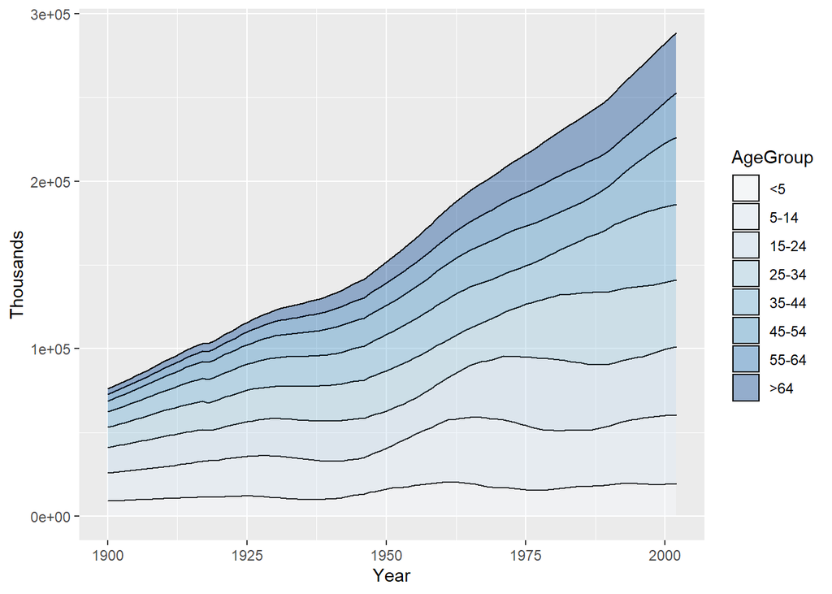

```r
uspopage %>%
  ggplot(aes(x = Year, y = Thousands, fill = AgeGroup)) +
  geom_area(color = "#000000", alpha = 0.4,
            position = position_stack(reverse = TRUE)) +
  scale_fill_brewer(palette = "Blues")
```

때에 따라 stacking되는 면적이 다각형 모양을 가지고 있어 outline을 그리면 잘못 읽을 우려가 있을 때가 있다.  
이런 경우에는 outline을 없애고 가장 위에 `geom_line()` layer을 추가하는 것이 좋다고 되어 있으나 현재 ggplot2에서는 차이가 없다.

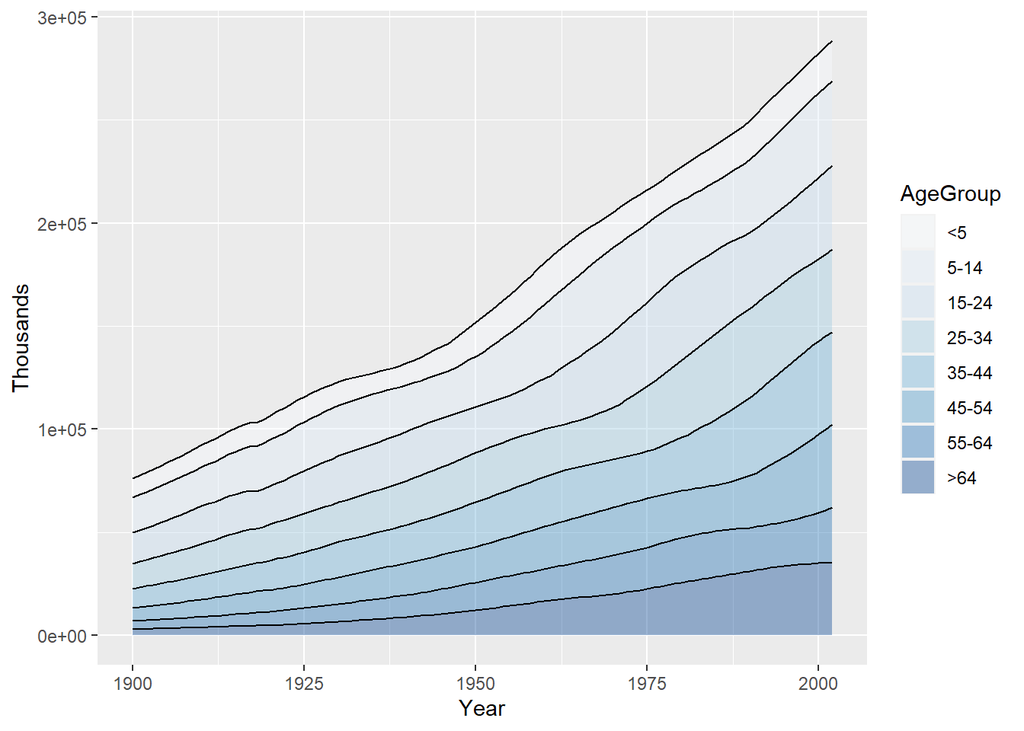

```r
uspopage %>%
  ggplot(aes(x = Year, y = Thousands, fill = AgeGroup)) +
  geom_area(color = NA, alpha = 0.4) +
  geom_line(position = "stack") +
  scale_fill_brewer(palette = "Blues")
```

### 4.8 Making a proportional stacked area graph

```r
uspopage_prop_old <-
  ddply(uspopage, "Year", transform,
        Percent = Thousands / sum(Thousands) * 100)

uspopage_prop_old
```

```
##     Year AgeGroup Thousands   Percent
## 1   1900       <5      9181 12.065340
## 2   1900     5-14     16966 22.296107
## 3   1900    15-24     14951 19.648067
## 4   1900    25-34     12161 15.981549
## 5   1900    35-44      9273 12.186243
## 6   1900    45-54      6437  8.459274
## 7   1900    55-64      4026  5.290825
## 8   1900      >64      3099  4.072594
## 9   1901       <5      9336 12.033409
## 10  1901     5-14     17158 22.115385
## 11  1901    15-24     15242 19.645803
## 12  1901    25-34     12442 16.036812
## 13  1901    35-44      9504 12.249948
## 14  1901    45-54      6606  8.514642
```

[output cut: 810 more lines]

```r
uspopage_prop <-
  uspopage %>%
  group_by(Year) %>%
  dplyr::mutate(Percent = Thousands / sum(Thousands) * 100) %>%
  ungroup()

uspopage_prop
```

```
## # A tibble: 824 x 4
##     Year AgeGroup Thousands Percent
##    <int> <fct>        <int>   <dbl>
##  1  1900 <5            9181   12.1
##  2  1900 5-14         16966   22.3
##  3  1900 15-24        14951   19.6
##  4  1900 25-34        12161   16.0
##  5  1900 35-44         9273   12.2
##  6  1900 45-54         6437    8.46
##  7  1900 55-64         4026    5.29
##  8  1900 >64           3099    4.07
##  9  1901 <5            9336   12.0
## 10  1901 5-14         17158   22.1
## # ... with 814 more rows
```

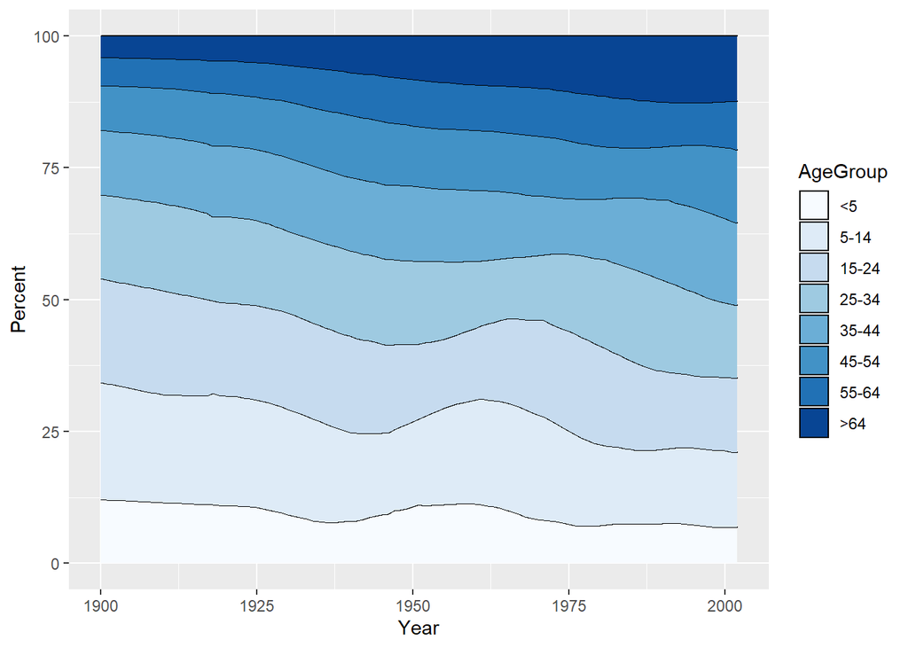

```r
uspopage_prop %>%
  ggplot(aes(x = Year, y = Percent, fill = AgeGroup)) +
  geom_area(color = "#000000", alpha = 4,
            position = position_stack(reverse = TRUE)) +
  scale_fill_brewer(palette = "Blues")
```

### 4.9 Adding a confidence region

그래프에 confidence region을 추가하기 위해서는 `geom_ribbon()`을 사용한다.  
`geom_ribbon()`은 `ymin`과 `ymax`값을 맵핑하여야 한다.  
`climate`data set의 Anomaly10y는 1950년에서 1980년까지 10년간의 평균 온도 편차를 나타낸 것이고, Unc10y는 95% 신뢰구간을 나타낸 것이다.  
Anomaly10y값에 Unc10값을 더하고 빼서 ymax값과 ymin값을 구한다.

```r
clim <-
  climate %>% subset(Source == "Berkeley", select = c("Year", "Anomaly10y", "Unc10y"))

clim
```

```
##     Year Anomaly10y Unc10y
## 1   1800     -0.435  0.505
## 2   1801     -0.453  0.493
## 3   1802     -0.460  0.486
## 4   1803     -0.493  0.489
## 5   1804     -0.536  0.483
## 6   1805     -0.541  0.475
## 7   1806     -0.590  0.468
## 8   1807     -0.695  0.461
## 9   1808     -0.763  0.453
## 10  1809     -0.818  0.451
## 11  1810     -0.842  0.437
## 12  1811     -0.912  0.406
## 13  1812     -0.963  0.395
## 14  1813     -1.015  0.389
```

[output cut: 191 more lines]

책에서는 투명도 때문에 방해가 되거나 선이 잘 보이지 않을 수 있기 때문에 `geom_ribbon()`을 `geom_line()` 보다 먼저 사용할 것을 권장하고 있다.  
하지만 순서를 바꿔서 해봐도 큰 차이를 느끼지 못해 그냥 보기 편한대로 순서에 관계없이 사용할 예정이다.

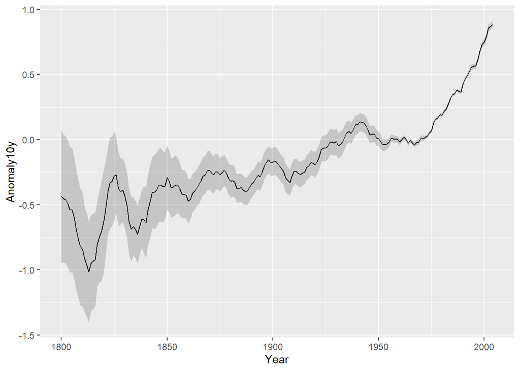

```r
clim %>%
  ggplot(aes(x = Year, y = Anomaly10y)) +
  geom_line() +
  geom_ribbon(aes(ymax = Anomaly10y + Unc10y, ymin = Anomaly10y - Unc10y),
              alpha = 0.2)
```

`geom_ribbon()`을 사용하여 shade를 하지 않고 upper/lower범위를 `geom_line()`으로 표현하는 방법도 있다.

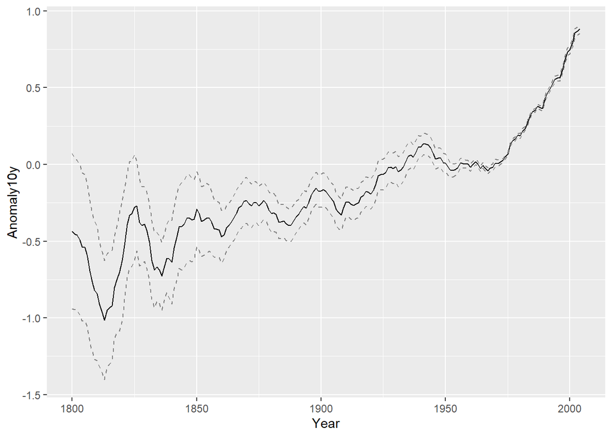

```r
clim %>%
  ggplot(aes(x = Year, y = Anomaly10y)) +
  geom_line() +
  geom_line(aes(y = Anomaly10y + Unc10y), color = "gray50", lty = 2) +
  geom_line(aes(y = Anomaly10y - Unc10y), color = "gray50", lty = 2)
```

**END**